# Análise de Dados 01

Arthur Campedelli, Eric Lee, Guilherme Fidalgo

2025-03-11

```r
library(tidyverse)
```

```r
library(ggplot2)
library(rsample)
library(glmnet)
library(rpart)
library(rpart.plot)
library(partykit)
library(ranger)
library(vip)
```

## Considerando os dados Sao Paulo Real Estate - Sale / Rent - April 2019, execute as seguintes tarefas:

```r
dados <- read.csv('sao-paulo-properties-april-2019.csv')
head(dados)
```

```
##   Price Condo Size Rooms Toilets Suites Parking Elevator Furnished
## 1   930   220   47     2       2      1       1        0         0
## 2  1000   148   45     2       2      1       1        0         0
## 3  1000   100   48     2       2      1       1        0         0
## 4  1000   200   48     2       2      1       1        0         0
## 5  1300   410   55     2       2      1       1        1         0
## 6  1170     0   50     2       2      1       1        0         0
##   Swimming.Pool New              District Negotiation.Type Property.Type
## 1             0   0 Artur Alvim/São Paulo             rent     apartment
## 2             0   0 Artur Alvim/São Paulo             rent     apartment
## 3             0   0 Artur Alvim/São Paulo             rent     apartment
## 4             0   0 Artur Alvim/São Paulo             rent     apartment
## 5             0   0 Artur Alvim/São Paulo             rent     apartment
## 6             0   0 Artur Alvim/São Paulo             rent     apartment
##    Latitude Longitude
## 1 -23.54314 -46.47949
## 2 -23.55024 -46.48072
## 3 -23.54282 -46.48566
## 4 -23.54717 -46.48301
## 5 -23.52502 -46.48244
## 6 -23.54875 -46.47720
```

### a) Calcule a frequência absoluta e relativa de cada categoria da variável “Negotiation.Type”.

Frequência absoluta:

```r
dados %>%
  count(Negotiation.Type)
```

```
##   Negotiation.Type    n
## 1             rent 7228
## 2             sale 6412
```

Frequência relativa:

```r
dados %>%
  count(Negotiation.Type) %>%
  mutate(percentagem = n / sum(n) * 100)
```

```
##   Negotiation.Type    n percentagem
## 1             rent 7228     52.9912
## 2             sale 6412     47.0088
```

### b) Faça um gráfico de dispersão do preço do condomínio e do preço anunciado. Como você descreveria esse tipo de relação?

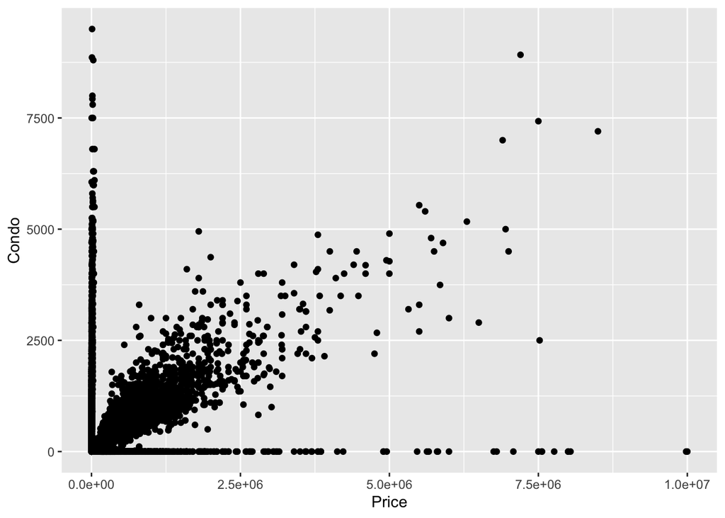

```r
dados %>%
  ggplot(aes(x = Price, y = Condo)) +
  geom_point()
```

A partir do gráfico podemos afirmar que á uma forte correlação linear positiva entre os preços do condomínio e o preço anunciado, ou seja, quanto maior o preço anunciado, maior o preço do condomínio. Porém temos que tomar cuidado com este gráfico pois ele mostra dados tanto para Sale (venda) quanto Rent (alguel), que possuem magnitudes de preço anunciado muito diferentes, então os dados que vemos plotados com correlação linear são em suma os de venda.

### c) Faça o gráfico do item anterior considerando facetas de acordo com “Negotiation.Type” (rent ou sale)

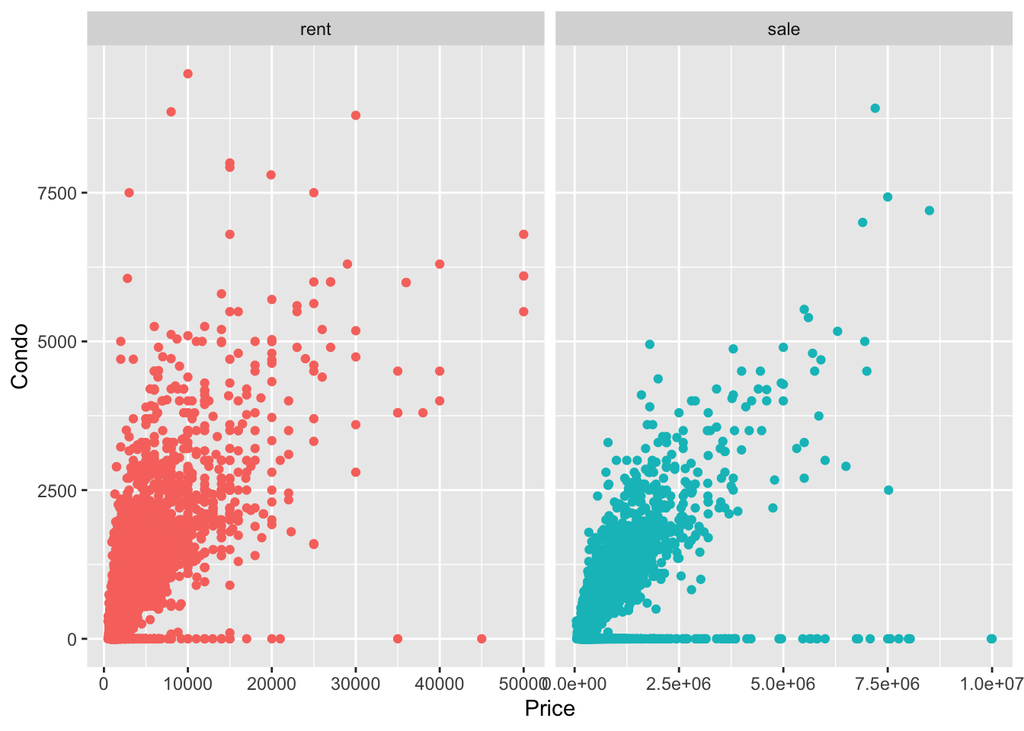

```r
dados %>%
  ggplot(aes(x = Price, y = Condo, color = Negotiation.Type)) +
  geom_point() +
  facet_wrap(~Negotiation.Type, scales = 'free_x') +
  theme(legend.position = 'none')
```

Por estes gráficos podemos confirmar que a forte correlação positiva ocorre tanto para imóveis anunciados para venda quanto para aluguel, em suas respectivas magnitudes, reforçando a conclusão do item anterior.

### d) Crie uma tabela para identificar quais são os dez distritos com maior frequência nesse banco de dados. Utilize essa tabela para criar um gráfico de frequências ordenado de forma decrescente.

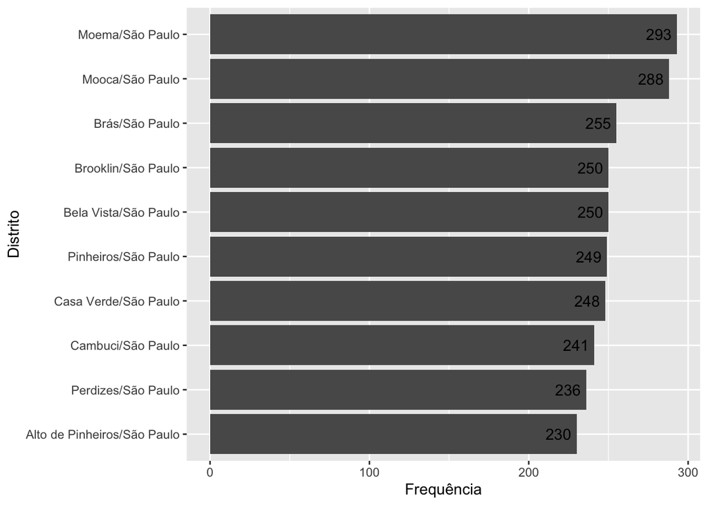

```r
maiores_distritos <- dados %>%
  count(District) %>%
  arrange(desc(n)) %>%
  head(10)

maiores_distritos %>%
  ggplot(aes(x = fct_reorder(District, n), y=n)) +
  geom_col() +
  geom_text(aes(label = n), hjust = 1.2) +
  coord_flip()+
  labs(x = 'Distrito', y='Frequência')
```

### e) Faça um filtro nos dados considerando apenas os dados de aluguel, separe os dados em dois conjuntos (treinamento e teste) e avalaie o erro de previsão para os seguintes modelos:

```r
dados_filtrados <- dados %>%
  filter(Negotiation.Type == 'rent')

set.seed(123)
splits <- initial_split(dados_filtrados, prop = 0.7)

dados_treino <- training(splits)
dados_teste <- testing(splits)

resultados <- tibble(modelo = character(), mse = double())

# Selecionando algumas features para o modelo de previsão
formula <- Price ~ Condo + Size + Rooms + Parking + Elevator + Furnished
```

#### i) regressão linear

```r
fit_linear <- lm(formula, data = dados_treino)
summary(fit_linear)
```

```
##
## Call:
## lm(formula = formula, data = dados_treino)
##
## Residuals:
##    Min     1Q Median     3Q    Max
## -19633   -660    -71    499  32895
##
## Coefficients:
##               Estimate Std. Error t value Pr(>|t|)
## (Intercept)  144.50586   97.02301   1.489    0.136
## Condo          1.04705    0.06661  15.719   <2e-16 ***
## Size          27.30668    1.01732  26.842   <2e-16 ***
## Rooms       -750.23322   51.47672 -14.574   <2e-16 ***
## Parking      808.91402   55.17667  14.660   <2e-16 ***
## Elevator      43.88359   65.84696   0.666    0.505
## Furnished   1014.18907   81.92628  12.379   <2e-16 ***
## ---
## Signif. codes:  0 '***' 0.001 '**' 0.01 '*' 0.05 '.' 0.1 ' ' 1
##
## Residual standard error: 2139 on 5052 degrees of freedom
## Multiple R-squared:  0.6304, Adjusted R-squared:   0.63
## F-statistic:  1436 on 6 and 5052 DF,  p-value: < 2.2e-16
```

```r
pred_linear <- predict(fit_linear, newdata = dados_teste)
erro_linear <- mean((dados_teste$Price - pred_linear)^2)

resultados <- resultados %>%
  add_row(modelo = 'Regressão Linear', mse = erro_linear)
```

#### ii) regressão ridge

```r
# Preparando os dados de forma matricial, já selecionando as mesmas colunas
x_treino <- model.matrix(formula, data = dados_treino)[, -1]
y_treino <- dados_treino$Price

x_teste <- model.matrix(formula, data = dados_teste)[, -1]
y_teste <- dados_teste$Price
```

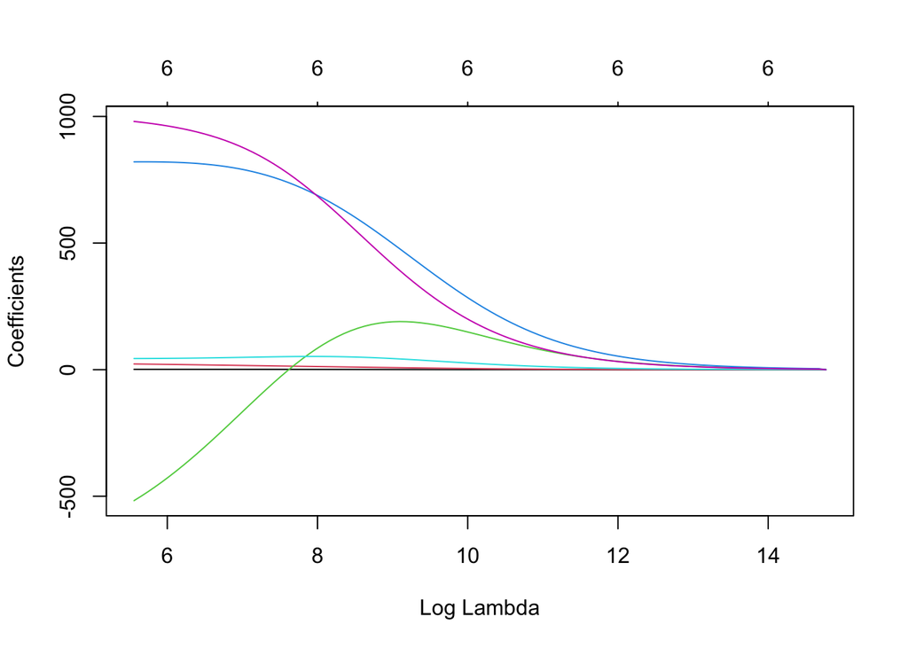

```r
fit_ridge <- glmnet(x_treino, y_treino, alpha = 0)
plot(fit_ridge, xvar='lambda')
```

```r
pred_ridge <- predict(fit_ridge, newx = x_teste)
erro_ridge <- mean((y_teste - pred_ridge)^2)

resultados <- resultados %>%
  add_row(modelo = 'Regressão Ridge', mse = erro_ridge)
```

#### iii) regressão LASSO

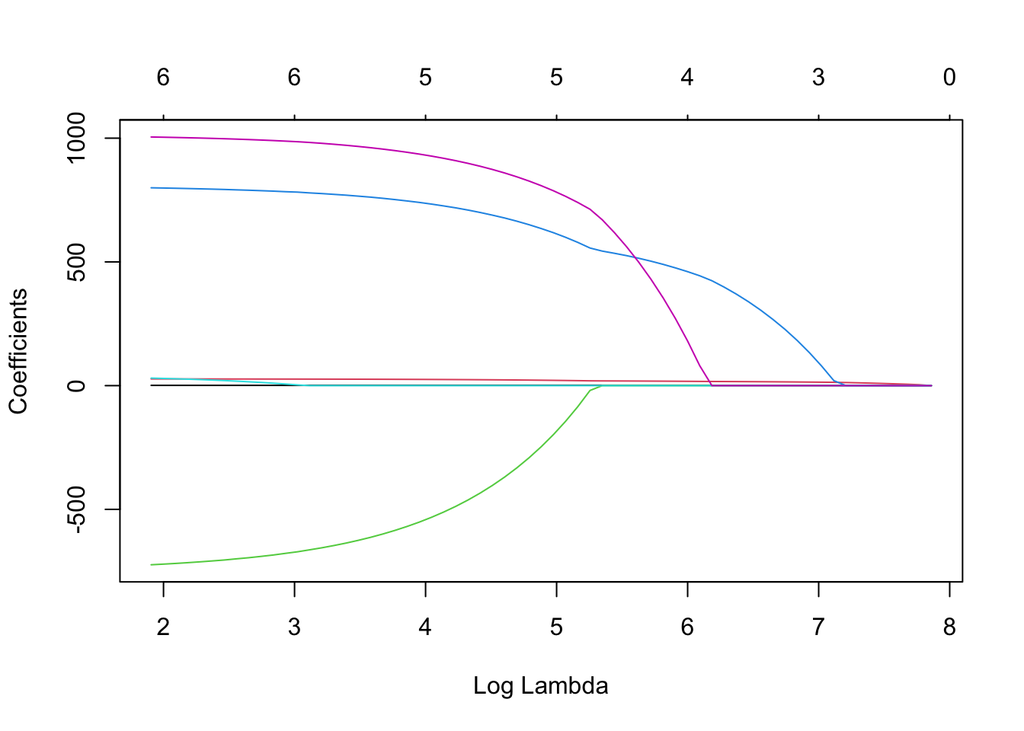

```r
fit_lasso <- glmnet(x_treino, y_treino, alpha = 1)
plot(fit_lasso, xvar='lambda')
```

```r
pred_lasso <- predict(fit_lasso, newx = x_teste)
erro_lasso <- mean((y_teste - pred_lasso)^2)

resultados <- resultados %>%
  add_row(modelo = 'Regressão LASSO', mse = erro_lasso)
```

#### iv) árvore de decisão

```r
fit_arvore <- rpart(formula, data = dados_treino)
summary(fit_arvore)
```

```
## Call:
## rpart(formula = formula, data = dados_treino)
##   n= 5059
##
##           CP nsplit rel error    xerror       xstd
## 1 0.39307658      0 1.0000000 1.0006201 0.08688363
## 2 0.08613106      1 0.6069234 0.6354130 0.05602134
## 3 0.07288239      2 0.5207924 0.5478608 0.04746368
## 4 0.01706685      3 0.4479100 0.4963977 0.04109572
## 5 0.01302689      4 0.4308431 0.4530306 0.03600973
## 6 0.01269917      5 0.4178162 0.4548919 0.03620510
## 7 0.01199446      6 0.4051171 0.4530279 0.03619338
## 8 0.01064758      7 0.3931226 0.4495910 0.03617759
## 9 0.01000000      8 0.3824750 0.4427667 0.03597082
##
## Variable importance
##    Size   Condo Parking   Rooms
##      43      32      17       8
##
## Node number 1: 5059 observations,    complexity param=0.3930766
##   mean=3063.205, MSE=1.2364e+07
##   left son=2 (4699 obs) right son=3 (360 obs)
##   Primary splits:
##       Size      < 187.5  to the left,  improve=0.39307660, (0 missing)
##       Condo     < 1797.5 to the left,  improve=0.37511690, (0 missing)
##       Parking   < 2.5    to the left,  improve=0.33914180, (0 missing)
##       Rooms     < 3.5    to the left,  improve=0.19359460, (0 missing)
##       Furnished < 0.5    to the left,  improve=0.02664553, (0 missing)
##   Surrogate splits:
##       Condo   < 2322.5 to the left,  agree=0.962, adj=0.472, (0 split)
##       Parking < 3.5    to the left,  agree=0.953, adj=0.342, (0 split)
##       Rooms   < 3.5    to the left,  agree=0.943, adj=0.206, (0 split)
##
## Node number 2: 4699 observations,    complexity param=0.08613106
##   mean=2453.013, MSE=3476008
##   left son=4 (3738 obs) right son=5 (961 obs)
##   Primary splits:
##       Condo     < 958.5  to the left,  improve=0.32983550, (0 missing)
##       Size      < 99.5   to the left,  improve=0.32913670, (0 missing)
##       Parking   < 1.5    to the left,  improve=0.24814540, (0 missing)
```

[output cut: 96 more lines]

```
##       Size    < 447    to the left,  agree=0.705, adj=0.235, (0 split)
##       Rooms   < 2.5    to the right, agree=0.659, adj=0.118, (0 split)
##       Parking < 6.5    to the left,  agree=0.636, adj=0.059, (0 split)
##
## Node number 26: 205 observations
##   mean=9883.815, MSE=2.550326e+07
##
## Node number 27: 24 observations
##   mean=15964.25, MSE=1.009874e+08
##
## Node number 30: 27 observations
##   mean=18533.33, MSE=7.981481e+07
##
## Node number 31: 17 observations
##   mean=26523.53, MSE=1.39503e+08
```

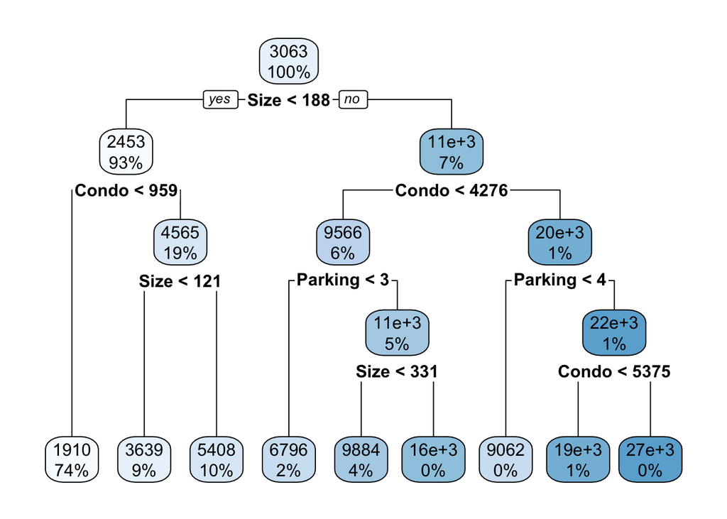

```r
rpart.plot(fit_arvore)
```

```r
# Descobrindo qual o melhor valor de cp
cp_values <- fit_arvore$cptable %>%
    as_tibble() %>%
    filter(xerror == min(xerror))
cp_values
```

```
## # A tibble: 1 × 5
##      CP nsplit `rel error` xerror   xstd
##   <dbl>  <dbl>       <dbl>  <dbl>  <dbl>
## 1  0.01      8       0.382  0.443 0.0360
```

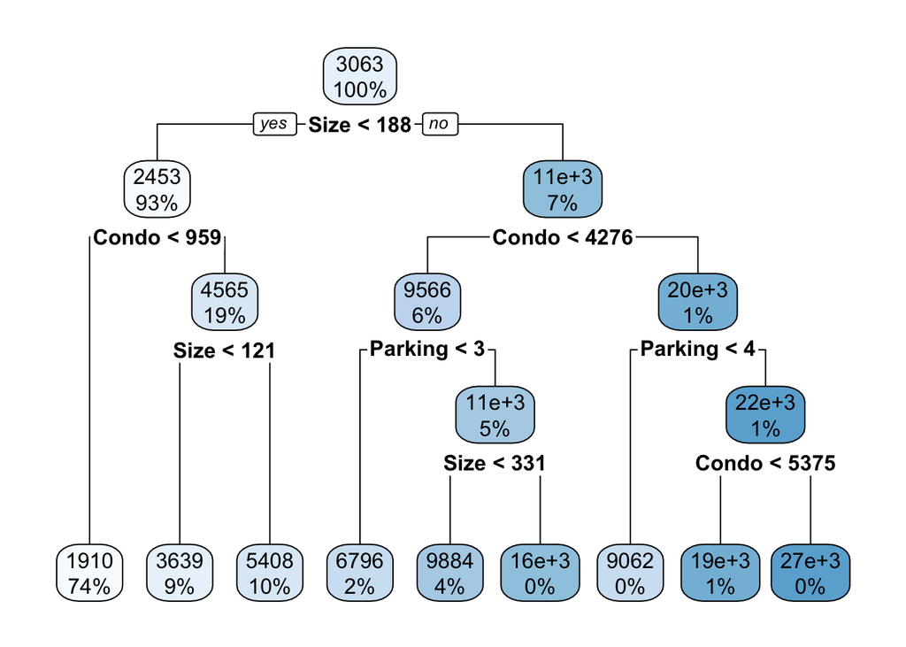

```r
# Fazendo a poda da árvore para este valor
fit_arvore_poda <- prune(fit_arvore, cp = cp_values$CP[1])
rpart.plot(fit_arvore_poda)
```

```r
pred_arvore <- predict(fit_arvore_poda, newdata = dados_teste)
erro_arvore <- mean((dados_teste$Price - pred_arvore)^2) # Erro quadrático médio

resultados <- resultados %>%
  add_row(modelo = 'Árvore de Decisão', mse = erro_arvore)
```

#### v) floresta aleatória

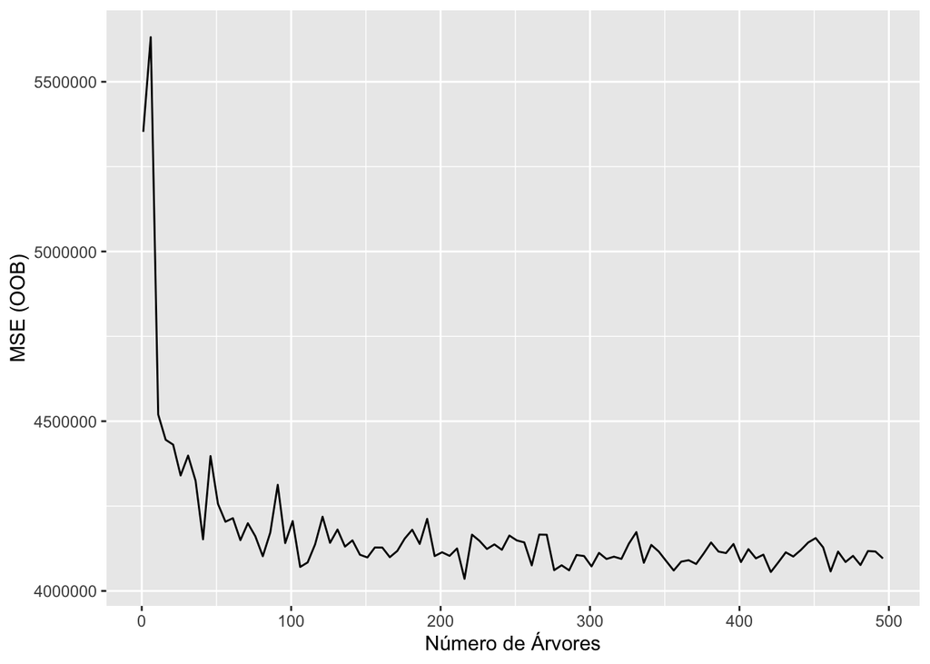

```r
set.seed(123)
fit_floresta <- ranger(formula, data = dados_treino)

set.seed(123)
result_floresta <- tibble(n_arvores = seq(1, 500, 5),
                          mse = NA)

for (i in 1:nrow(result_floresta)) {
  rf <- ranger(formula, num.trees = result_floresta$n_arvores[i], data = dados_treino)
  result_floresta$mse[i] <- rf$prediction.error
}

result_floresta %>%
  ggplot(aes(n_arvores, mse)) +
  geom_line() +
  labs(x='Número de Árvores', y = 'MSE (OOB)')
```

```r
result_floresta <- crossing(mtry = c(1, 2, 3, 4, 5, 6),
                            n_arvores = c(1:10, seq(10,500,10)))

ajusta <- function(mtry, n_arvores) {
  rf <- ranger(formula, num.trees = n_arvores, mtry = mtry, data = dados_treino)
  return(rf$prediction.error)
}

result_floresta <- result_floresta %>%
  mutate(mse = map2_dbl(mtry, n_arvores, ajusta))
head(result_floresta)
```

```
## # A tibble: 6 × 3
##    mtry n_arvores      mse
##   <dbl>     <dbl>    <dbl>
## 1     1         1 9070831.
## 2     1         2 6352520.
## 3     1         3 5762867.
## 4     1         4 6429428.
## 5     1         5 4877316.
## 6     1         6 6044746.
```

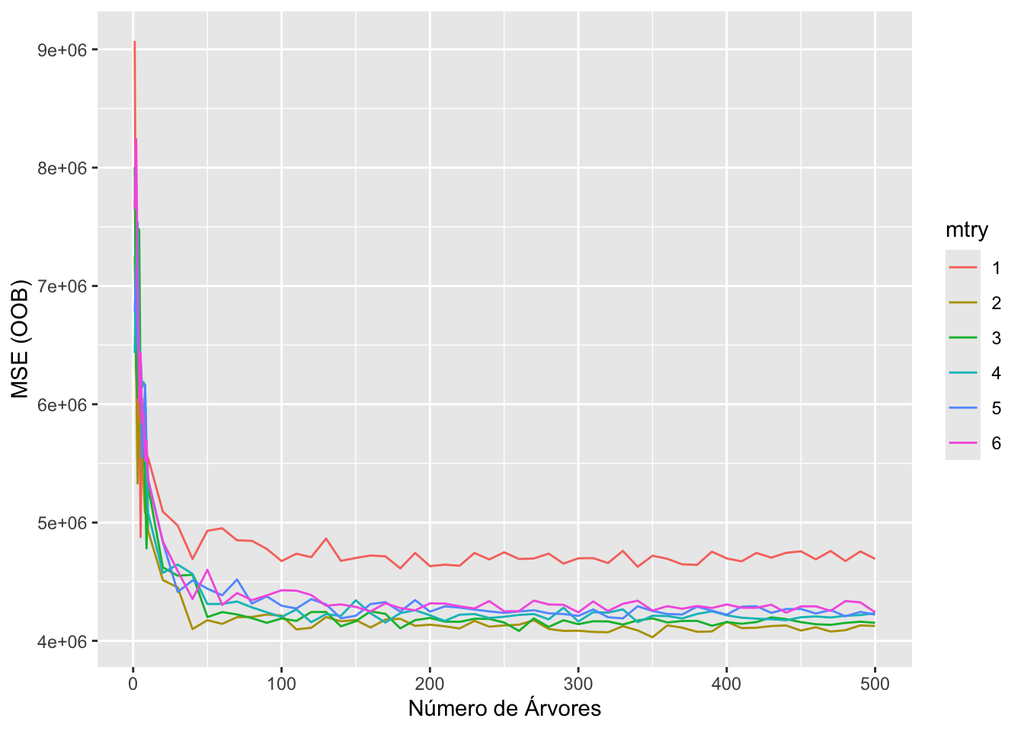

```r
result_floresta %>%
  mutate(mtry = as.factor(mtry)) %>%
  ggplot(aes(n_arvores, mse, color = mtry)) +
  geom_line() +
  labs(x = 'Número de Árvores', y = 'MSE (OOB)')
```

Descobrimos que o mtry =2 é o melhor valor para MSE e que ao redor de 100 árvores é o melhor valor para o número de árvores

```r
fit_floresta_ajustada <- ranger(formula, num.trees = 100, mtry = 2, data = dados_treino)

pred_floresta <- predict(fit_floresta_ajustada, data = dados_teste)$predictions
erro_floresta <- mean((dados_teste$Price - pred_floresta)^2)

resultados <- resultados %>%
  add_row(modelo = 'Floresta Aleatória', mse = erro_floresta)
```

```r
resultados %>%
  mutate(rmse = sqrt(mse)) %>%
  arrange(mse)
```

```
## # A tibble: 5 × 3
##   modelo                  mse  rmse
##   <chr>                 <dbl> <dbl>
## 1 Floresta Aleatória 4851938. 2203.
## 2 Regressão Linear   5439518. 2332.
## 3 Regressão LASSO    6189543. 2488.
## 4 Árvore de Decisão  6356070. 2521.
## 5 Regressão Ridge    9046672. 3008.
```

A partir da análise dos Erros Quadrático Médios de todos os modelos podemos afirmar que a Floresta Aleatória possui melhores características preditoras para o preço de aluguel dos imóveis